# StreptoHTA Group 4 Assignment

For this work we made use of the template developed by the Decision Analysis in R for Technologies in Health (DARTH) workgroup: http://darthworkgroup.com.

The notation of our code is based on the following provided framework and coding convention: Alarid-Escudero, F., Krijkamp, E., Pechlivanoglou, P. et al. A Need for Change! A Coding Framework for Improving Transparency in Decision Modeling. PharmacoEconomics 37, 1329–1339 (2019). https://doi.org/10.1007/s40273-019-00837-x.

Other work from DARTH can be found on the website: http://darthworkgroup.com/publications/

# Is Throat Culture More Cost-Effective than Rapid Antigen Diagnostic Testing (RADT) for Diagnosing Group A Streptococcus (GAS) in Pediatric Sore Throat Patients?

In this exercise, we will model Group A Streptococcal (GAS) pharyngitis using an individual-based state-transition model, commonly referred to as a micro-simulation model. This model will simulate the progression of patients experiencing sore throat symptoms, incorporating two diagnostic strategies: Rapid Antigen Detection Test (RADT) and Throat Culture (TC).

Disclaimer: The input parameters used were inspired by the literature but were not copied 1:1.

**Table 1: Input parameters for the time dependent Sick-Sicker Microsimulation**

[output not shown]

# 01 Load packages

```r
if (!require('pacman')) install.packages('pacman')

library(pacman) # use this package to conveniently install other packages
# load (install if required) packages from CRAN
p_load("dplyr", "tidyr", "reshape2", "devtools", "scales", "ellipse", "ggplot2", "ggrepel", "gridExtra", "lazyeval", "igraph", "truncnorm", "ggraph", "reshape2", "patchwork", "knitr", "stringr", "diagram", "ggthemes")
library(dampack)
# load (install if required) packages from GitHub
# install_github("DARTH-git/darthtools", force = TRUE) #Uncomment if there is a newer version

p_load_gh("DARTH-git/darthtools")
```

# 02 Load functions

```r
# all needed functions are in the darthtools package
```

# 03 Model input

```r
## General setup
set.seed(1)               # set the seed
cycle_length   <- 1/12       # cycle length equal to one year (use 1/12 for monthly)
n_cycles       <- 24      # time horizon, number of cycles
n_i            <- 10000  # number of individuals

# the 4 health states of the model:
v_names_states  <- c("H",  # Healthy (H)
                     "S", # Sick (S)
                     "D")  # Dead (D)
v_names_cycles  <- paste("cycle", 0:n_cycles)    # cycle names
n_states        <- length(v_names_states) # number of health states

### Discounting factors
d_c <- 0.03 # monthly discount rate for costs
d_e <- 0.03 # monthly discount rate for QALYs


### Strategies
v_names_str   <- c("Standard of care",   # This is the RADT
                   "Strategy AB")        # Throat Culture
n_str         <- length(v_names_str)     # number of strategies

### Transition probabilities
p_HS            <- 1 - (1 - 0.25)^(1/12)
p_SH_SoC         <- 1 - (1 - 0.88)^(1/12)      # probability of recovering to healthy when sick and diagnosed through SoC
p_SH_diagAB          <- 1 - (1 - 0.93)^(1/12)  # probability of recovering to healthy when sick and diagnosed through AB


# Monthly probabilities of death
# load age dependent probability
p_mort   <- read.csv("data/mortProb_age.csv")
# Adjust to monthly probabilities
p_mort$p_HD <- 1 - (1 - p_mort$p_HD)^(1/12)

# load age distribution
dist_Age <- read.csv("data/MyPopulation-AgeDistribution.csv")

# probability to die in S by cycle (is increasing)
v_p_SD <- 1 - (1 - c(0.005, 0.007, 0.01, 0.02, 0.03, rep(0.04, n_cycles - 5)))^(1/12)


### State rewards
#### Costs
c_H     <- 500 / 12  # monthly cost of being Healthy
c_S     <- 750 / 12  # monthly cost of being Sick
c_D     <- 0     # monthly cost of being dead
c_diagSoC <- 30 # monthly cost (for this assignment) of receiving diagnosis SoC + treatment when in Sick
c_diagAB <- 70 # monthly cost (for this assignment) of receiving diagnosis AB + treatment when in Sick

#### Utilities
u_H     <- 1     # monthly utility of being Healthy
u_S     <- 0.85  # monthly utility of being Sick
u_D     <- 0     # monthly utility of being dead
u_diagAB <- 0.95  # monthly utility when receiving diagnosis AB when in Sick

wtp = 5000 # Fictional Willingness-to-pay threshold
```

```r
m_P_diag <- matrix(0, nrow = n_states, ncol = n_states, dimnames = list(v_names_states, v_names_states))
m_P_diag["H", "H" ] = ""
m_P_diag["H", "S" ] = ""
m_P_diag["H", "D" ] = ""

m_P_diag["S", "H"] = ""
m_P_diag["S", "S" ] = ""
m_P_diag["S", "D" ] = ""

m_P_diag["D", "D" ] = ""

layout.fig <- c(2, 1)

# Save plot as PNG
png("figs/transition_diagram.png", width = 800, height = 600)
# Generate the plot
plotmat(t(m_P_diag), t(layout.fig), self.cex = 0.5, curve = 0.04, arr.pos = 0.7,
        latex = T, arr.type = "curved", relsize = 0.85, box.prop = 0.8,
        cex = 0.8, box.cex = 0.7, lwd = 1)
# Close the graphical device
dev.off()
```

## Calculate internal model parameters

```r
### Discount weight for costs and effects
v_dwc <- (1 / (1 + d_c)^(1/12)) ^ (0:n_cycles)
v_dwe <- (1 / (1 + d_e)^(1/12)) ^ (0:n_cycles)

# Within-cycle correction (WCC) - method  options Simpson's 1/3 rule, "half-cycle" or "none"
v_wcc    <- darthtools::gen_wcc(n_cycles = n_cycles,
                                method = "Simpson1/3") # vector of wcc
```

# 04 Sample individual level characteristics

## 04.1 Static characteristics

```r
# sample the treatment effect modifier at baseline
v_x     <- runif(n_i, min = 0.95, max = 1.05)
# sample from the age distribution the initial age for every individual
v_age0  <- sample(x = dist_Age$age, prob = dist_Age$prop, size = n_i, replace = TRUE)
```

## 04.2 Dynamic characteristics

Here, we specify the information regarding the initial health states of the individuals as well as in which health state each of the individuals start.

```r
v_M_init  <- rep("H", times = n_i)   # Specify the initial health state of the individuals
v_n_cycles_s_init <- rep(0, n_i)  # everyone begins in the healthy state (in this example)
```

## 04.3 Create a dataframe with the individual characteristics

Now, we merge the static and dynamic individual characteristics into one dataframe.

```r
# data frame with each individual's
# ID number, treatment effect modifier, age and initial time in sick state and initial health state at the start of the simulation
df_X  <- data.frame(ID = 1:n_i, M_x = v_x, Age = v_age0, n_cycles = v_n_cycles_s_init, M_init = v_M_init)

head(df_X)  # print the first rows of the dataframe
```

```
##   ID       M_x Age n_cycles M_init
## 1  1 0.9765509  10        0      H
## 2  2 0.9872124  15        0      H
## 3  3 1.0072853  17        0      H
## 4  4 1.0408208   9        0      H
## 5  5 0.9701682  10        0      H
## 6  6 1.0398390   9        0      H
```

```r
# See also:
# Define the plot
p <- ggplot(df_X, aes(x = Age)) +
    geom_histogram()
# Save the plot as PNG
ggsave("figs/histogram_age.png", plot = p, width = 8, height = 6, dpi = 300)
```

# 05 Define Simulation Functions

## 05.1 Probability function

```r
Probs <- function(M_t, df_X, Diag = "SoC") {
  # Arguments:
    # M_t:  health state occupied at cycle t (character variable)
    # df_X: data frame with individual characteristics data
    # Diag:  diagnosis
  # Returns:
    # transition probabilities for that cycle

# Diagnosis specific transition probabilities
  if (Diag == "SoC") {
    p_SH <- p_SH_SoC
  } else if (Diag == "AB") {
    p_SH <- p_SH_diagAB
  }

# ### Age specific transition probabilities
#   p_HS_age <- df_X
#   p_HS_age$p_HS <- ifelse(p_HS_age$Age > 18, 0.1, 0.4)
#
#   p_HS         <- 1 - (1 - p_HS_age$p_HS)^(1/12)     # probability of becoming sick when healthy for monthly cycle
#
  # create matrix of state transition probabilities
  m_p_t           <- matrix(data = 0, nrow = n_states, ncol = n_i)
  # give the state names to the rows
  rownames(m_p_t) <-  v_names_states

  # lookup baseline probability and rate of dying based on individual characteristics
  p_HD_all <- inner_join(x = df_X, y = p_mort, by = c("Age"))
  p_HD     <- p_HD_all[M_t == "H", "p_HD"]

  # # lookup baseline probability and rate of becoming sick based on individual characteristics (Age)
  # p_HS_all <- inner_join(x = df_X, y = df_p_sick, by = c("Age"))
  # p_HS     <- p_HS_all[M_t == "H", "p_HS"]

  # update m_p_t with the appropriate probabilities
  # (all non-death probabilities are conditional on survival)
  # transition probabilities when Healthy
  m_p_t["H", M_t == "H"] <- (1 - p_HD) * (1 - p_HS)
  m_p_t["S", M_t == "H"] <- (1 - p_HD) * p_HS
  m_p_t["D", M_t == "H"] <-      p_HD


  # transition probabilities when Sick
  m_p_t["H", M_t == "S"] <-  (1 - v_p_SD[df_X$n_cycles]) * p_SH
  m_p_t["S", M_t == "S"] <-  (1 - v_p_SD[df_X$n_cycles]) * (1 - p_SH)
  m_p_t["D", M_t == "S"] <-      v_p_SD[df_X$n_cycles]


  # transition probabilities when Dead
  m_p_t["H", M_t == "D"] <- 0
  m_p_t["S", M_t == "D"] <- 0
  m_p_t["D", M_t == "D"] <- 1

  return(t(m_p_t))
}
```

## 05.2 Cost function

The `Costs` function estimates the costs at every cycle.

```r
Costs <- function (M_t, Diag = "SoC") {
  # Arguments:
    # M_t: health state occupied at cycle t (character variable)
    # Diag:  diagnosis
  # Returns:
    # costs accrued in this cycle

    # Diagnosis specific costs
  if (Diag == "SoC") {
    c_diag <- c_diagSoC
  } else if (Diag == "AB") {
    c_diag <- c_diagAB
  }

  c_t <- c()
  c_t[M_t == "H"] <- c_H  # costs accrued by being healthy this cycle
  c_t[M_t == "S"] <- c_S + c_diag         # costs accrued by being sick this cycle
  c_t[M_t == "D"] <- c_D          # costs at dead state

  return(c_t)  # return costs accrued this cycle
}
```

## 05.3 Health outcome function

The `Effs` function to update the utilities at every cycle.

```r
Effs <- function (M_t, cycle_length = 1, Diag = "SoC") {
  # Arguments:
    # M_t: health state occupied at cycle t (character variable)
    # cl:  cycle length (default is 1)
    # df_X: data frame with individual characteristics data (TA added)
    # Diag:  Diagnosis
  # Returns:
    # QALYs accrued this cycle

  u_t <- 0                          # by default the utility for everyone is zero
  u_t[M_t == "H"]    <- u_H         # update the utility if healthy

  if (Diag == "SoC") {  # update the utility if sick under standard of care
    u_t[M_t == "S"] <- u_S
  } else if (Diag == "AB") {
    u_t[M_t == "S"] <- u_diagAB * df_X$x[M_t == "S"]
  }

  u_t[M_t == "D"]    <- u_D         # update the utility if dead

  QALYs <- u_t * cycle_length  # calculate the QALYs during cycle t
  return(QALYs)      # return the QALYs accrued this cycle
}
```

## 05.4 The Micro-simulation function

```r
MicroSim <- function(n_i, df_X, Diag = "SoC", seed = 1, cycle_length = 1, verbose ) {
  # Arguments:
    # n_i: number of individuals
    # df_X: data frame with individual data
    # Diag: diagnosis
    # seed: seed for the random number generator, default is 1
    # cycle_length: cycle length
  # Returns:
    # results: data frame with total cost and QALYs

  set.seed(seed) # set a seed to be able to reproduce the same results

  # Here, we create three matrices called m_M, m_C and m_E
  # number of rows is equal to the n_i, the number of columns is equal to n_cycles
  # (the initial state and all the n_cycles cycles)
  # m_M is used to store the health state information over time for every individual
  # m_C is used to store the costs information over time for every individual
  # m_E is used to store the effects information over time for every individual

  m_M <- m_C <- m_E <-  matrix(nrow = n_i, ncol = n_cycles + 1,
                               dimnames = list(paste("ind"  , 1:n_i, sep = " "),
                                               paste("cycle", 0:n_cycles, sep = " ")))

  m_M[, 1] <- as.character(df_X$M_init) # initial health state at cycle 0 for individual i
  m_C[, 1] <- Costs(m_M[, 1])           # costs per individual during cycle 0
  m_E[, 1] <- Effs( m_M[, 1], cycle_length = cycle_length)   # QALYs per individual during cycle 0

  # open a loop for time running cycles 1 to n_cycles
  for (t in 1:n_cycles) {
    print(t)
    # calculate the transition probabilities for the cycle based on health state t
    m_P <- Probs(m_M[, t], df_X, Diag = Diag)
    # check if transition probabilities are between 0 and 1
    check_transition_probability(m_P, verbose = TRUE)
    # check if each of the rows of the transition probabilities matrix sum to one
    check_sum_of_transition_array(m_P, n_rows = n_i, n_cycles = n_cycles, verbose = TRUE)

    # sample the next health state and store that state in matrix m_M
    m_M[, t + 1]  <- samplev(m_P, 1)
    # calculate costs per individual during cycle t + 1
    m_C[, t + 1]  <- Costs(m_M[, t + 1], Diag = Diag)
    # calculate QALYs per individual during cycle t + 1
    m_E[, t + 1]  <- Effs (m_M[, t + 1], cycle_length = cycle_length)

    # update time since illness onset for t + 1
    # NOTE: this code has a "reset of history" for time being sick
    # once someone is not "Sick" anymore, we reset n_cycles (set back to zero)
    # when you don't want a "reset" replace the last zero with the current value
    df_X$n_cycles <- if_else(m_M[, t + 1] == "S", df_X$n_cycles + 1, 0)
    # update the age of individuals that are alive
    df_X$Age[m_M[, t + 1] != "D"]  <- df_X$Age[m_M[, t + 1] != "D"] + 1

    # Display simulation progress
    if(t/(n_cycles/10) == round(t/(n_cycles/10), 0)) { # display progress every 10%
      cat('\r', paste(t/n_cycles * 100, "% done", sep = " "))
    }

  } # close the loop for the time points

  # Discounted total expected QALYs and Costs per strategy and apply cycle correction
  tc      <- m_C %*% (v_dwc * v_wcc)  # total (discounted and cycle corrected) cost per individual
  te      <- m_E %*% (v_dwe * v_wcc)  # total (discounted and cycle corrected) QALYs per individual

  tc_hat  <- mean(tc)       # average (discounted and cycle corrected) cost
  te_hat  <- mean(te)       # average (discounted and cycle corrected) QALY
  # store the results from the simulation in a list
  results <- list(m_M = m_M, m_C = m_C, m_E = m_E, tc = tc , te = te,
                  tc_hat = tc_hat, te_hat = te_hat)

  return(results)  # return the results

}
```

# 06 Run Microsimulation

```r
outcomes_SoC  <- MicroSim(n_i = n_i, df_X = df_X, seed = 1, cycle_length = cycle_length, Diag = "SoC")  # Run for Standard of Care
outcomes_diagAB <- MicroSim(n_i = n_i, df_X = df_X, seed = 1, cycle_length = cycle_length, Diag = "AB") # Run simulation for strategy AB
```

# 07 Visualize results

```r
# Standard of Care
# Save the first plot (Total Cost per Person)
png("figs/SoC_total_cost_per_person.png", width = 800, height = 600)
plot(density(outcomes_SoC$tc), main = "Total cost per person", xlab = "Cost ($)")
dev.off()
```

```r
# Save the second plot (Total QALYs per Person)
png("figs/SoC_total_qalys_per_person.png", width = 800, height = 600)
plot(density(outcomes_SoC$te), main = "Total QALYs per person", xlab = "QALYs")
dev.off()
```

```r
# Save the third plot (Health State Trace)
png("figs/SoC_health_state_trace.png", width = 800, height = 600)
plot_trace_microsim(outcomes_SoC$m_M)
dev.off()
```

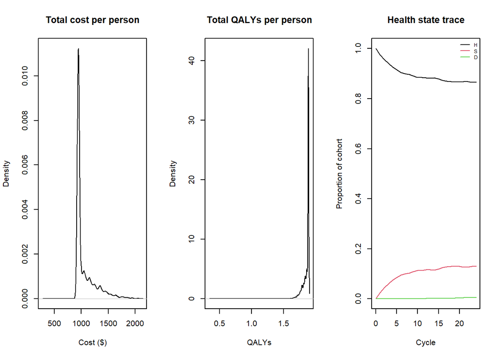

```r
# Show all plots in R (without saving)
par(mfrow = c(1, 3))  # Arrange plots in 1 row, 3 columns
plot(density(outcomes_SoC$tc), main = "Total cost per person", xlab = "Cost ($)")
plot(density(outcomes_SoC$te), main = "Total QALYs per person", xlab = "QALYs")
plot_trace_microsim(outcomes_SoC$m_M)
```

```r
par(mfrow = c(1, 1))  # Reset layout
```

The first plot represents the distribution of total costs per person. The cost distribution is right-skewed, indicating that while most individuals accumulate costs around $1000, a smaller proportion incurs significantly higher costs. The density spike suggests that the majority of individuals have similar healthcare expenditures.

The second plot illustrates the distribution of total quality-adjusted life years (QALYs) per individual. There is a pronounced peak around 2 QALYs, indicating that most individuals maintain a relatively stable quality of life throughout the simulation. The distribution is narrow, suggesting little variability in health outcomes among individuals.

The third graph tracks the proportion of individuals in each health state over 24 cycles. Initially, all individuals start in the Healthy (H) state, but over time, an increasing proportion transitions into the Sick (S) state. The Sick state proportion rises gradually before stabilizing. Meanwhile, the proportion of deceased individuals (D) grows very slowly, indicating a gradual accumulation of low mortality events. The total proportion of the cohort always sums to 1, ensuring consistency in state transitions.

```r
# Strategy AB
# Save the first plot (Total Cost per Person)
png("figs/AB_total_cost_per_person_AB.png", width = 800, height = 600)
plot(density(outcomes_diagAB$tc), main = "Total cost per person (Diagnosis AB)", xlab = "Cost ($)")
dev.off()
```

```r
# Save the second plot (Total QALYs per Person)
png("figs/AB_total_qalys_per_person_AB.png", width = 800, height = 600)
plot(density(outcomes_diagAB$te), main = "Total QALYs per person (Diagnosis AB)", xlab = "QALYs")
dev.off()
```

```r
# Save the third plot (Health State Trace)
png("figs/AB_health_state_trace_AB.png", width = 800, height = 600)
plot_trace_microsim(outcomes_diagAB$m_M)
dev.off()
```

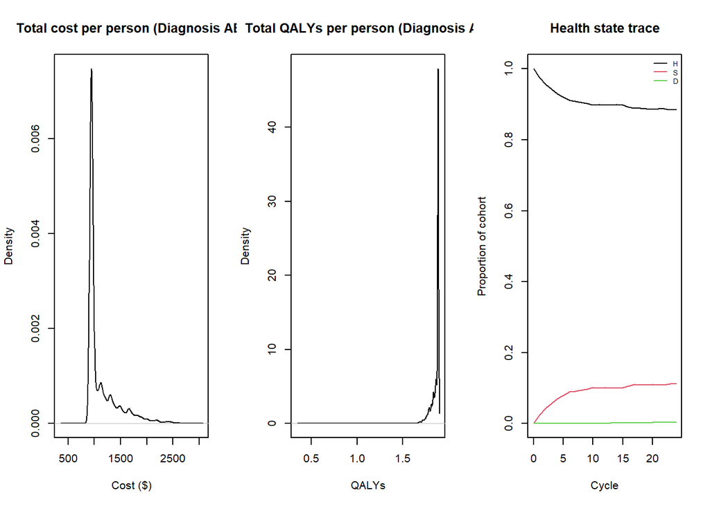

```r
# Show all plots in R (without saving)
par(mfrow = c(1, 3))  # Arrange plots in 1 row, 3 columns
plot(density(outcomes_diagAB$tc), main = "Total cost per person (Diagnosis AB)", xlab = "Cost ($)")
plot(density(outcomes_diagAB$te), main = "Total QALYs per person (Diagnosis AB)", xlab = "QALYs")
plot_trace_microsim(outcomes_diagAB$m_M)
```

```r
par(mfrow = c(1, 1))  # Reset layout
```

The first plot represents the distribution of total costs per person. The cost distribution is heavily right-skewed, with a sharp peak around $1000. This suggests that most individuals have relatively similar healthcare costs, while a small proportion experiences significantly higher expenses.

The third graph tracks the proportion of individuals in each health state over 24 cycles. Initially, all individuals start in the Healthy (H) state, but over time, an increasing proportion transitions into the Sick (S) state. The Sick state proportion rises gradually before stabilizing. Meanwhile, the proportion of deceased individuals (D) grows very slowly, indicating a gradual accumulation of low mortality events.

# 08 Cost-effectiveness analysis (CEA)

```r
# store the mean costs of each strategy in a new variable C (vector of costs)
v_C <- c(outcomes_SoC$tc_hat, outcomes_diagAB$tc_hat)
# store the mean QALYs of each strategy in a new variable E (vector of effects)
v_E <- c(outcomes_SoC$te_hat, outcomes_diagAB$te_hat)

# use dampack to calculate the ICER
df_cea <- calculate_icers(cost       = v_C,
                          effect     = v_E,
                          strategies = v_names_str)
df_cea
```

```
##           Strategy     Cost   Effect Inc_Cost  Inc_Effect     ICER Status
## 1 Standard of care 1062.215 1.855369       NA          NA       NA     ND
## 2      Strategy AB 1131.389 1.859744 69.17367 0.004374874 15811.58     ND
```

```r
## CEA table in proper format
table_cea <- format_table_cea(df_cea)

# Save the table as a CSV file
write.csv(table_cea, "tables/CEA_table.csv", row.names = FALSE)
# For use in R:
saveRDS(table_cea, "tables/CEA_table.rds")
# table_cea <- readRDS("tables/CEA_table.rds")
table_cea
```

```
##           Strategy Costs ($) QALYs Incremental Costs ($) Incremental QALYs
## 1 Standard of care     1,062  1.86                  <NA>                NA
## 2      Strategy AB     1,131  1.86                    69                 0
##   ICER ($/QALY) Status
## 1          <NA>     ND
## 2        15,812     ND
```

```r
## CEA frontier
# Save as PNG
png("figs/cea_plot.png", width = 800, height = 600)
# Generate the plot
plot(df_cea, label = "all", txtsize = 14) +
  theme(legend.position = c(0.8, 0.3))
# Close the graphical device
dev.off()
```

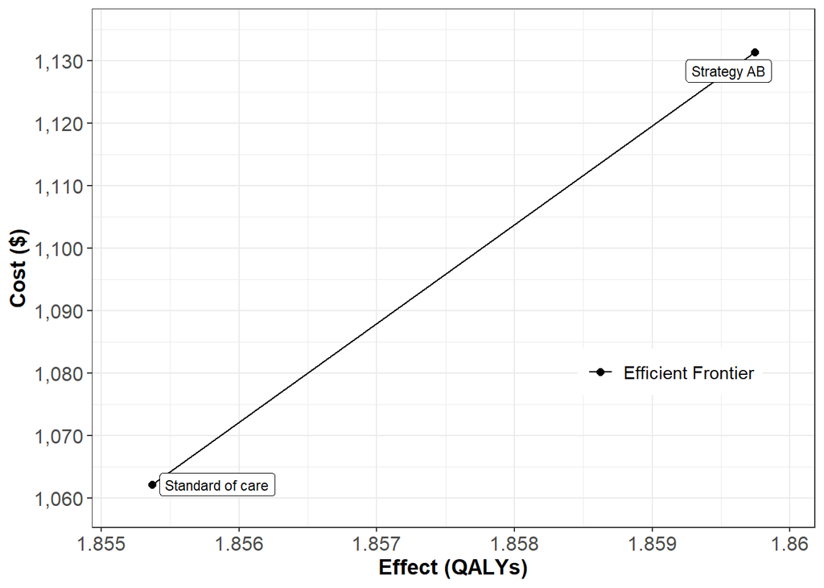

```r
# Show the plot
plot(df_cea, label = "all", txtsize = 14) +
  theme(legend.position = c(0.8, 0.3))
```

- Strategy AB is more expensive but provides almost no additional benefit (QALYs are nearly the same as SoC).
- If the willingness-to-pay threshold is low, Strategy AB is not worth adopting, as the cost increase outweighs the marginal benefit.
- SoC remains a reasonable choice given its lower cost with almost identical effectiveness.

# 09 Deterministic Sensitivity Analysis

```r
## Load model, CEA and PSA
source('functions/Functions_StreptoHTA.R')
```

## 09.1 Model input for SA

```r
l_params_all <- list(

  cycle_length    = 1/12,                             # cycle length equal to one year (use 1/12 for monthly)
  n_cycles        = 24,                            # number of cycles

  v_names_states  = c("H", "S", "D"),  # state names

  n_i             = 10000 ,                        # number of individuals

  ### Strategies
  v_names_str     = c("Standard of Care",         # store the strategy names
                     "Diagnosis AB")  ,

  # Transition probabilities
  # probability of dying
  p_HS         = 1 - (1 - 0.1)^(1/12),     # probability of becoming sick when healthy

  p_HS_child = 1 - (1 - 0.4)^(1/12),  # probability healthy -> dead when female
  p_HS_adult   = 1 - (1 - 0.1)^(1/12),  # probability healthy -> dead when male

  p_SH_SoC         = 1 - (1 - 0.88)^(1/12),      # probability of recovering to healthy when sick and diagnosed through SoC
  p_SH_diagAB          = 1 - (1 - 0.93)^(1/12),  # probability of recovering to healthy when sick and diagnosed through AB


  # Costs
  c_H     = 500 / 12,  # monthly cost of being Healthy
  c_S     = 750 / 12,  # monthly cost of being Sick
  c_D     = 0,     # monthly cost of being dead
  c_diagSoC = 30, # monthly (very inflated) cost (for this assignment) of receiving diagnosis SoC + treatment when in Sick
  c_diagAB = 70, # monthly (very inflated) cost (for this assignment) of receiving diagnosis AB + treatment when in Sick


  # Utilities
  u_H     = 1,     # monthly utility of being Healthy
  u_S     = 0.85,  # monthly utility of being Sick
  u_D     = 0,     # monthly utility of being dead
  u_diagAB = 0.95,  # monthly utility when receiving diagnosis AB when in Sick

  # Discount rates
  d_e       = 0.03,  # discount rate per cycle equal discount of costs and QALYs by 3%
  d_c       = 0.03  # discount rate per cycle equal discount of costs and QALYs by 3%
)
```

## 09.2 Run the function with the list of parameters

```r
df_ce <- calculate_ce_out(l_params_all)


# use dampack to calculate the ICER
calculate_icers(cost       = df_ce$Cost,
                effect     = df_ce$Effect,
                strategies = df_ce$Strategy)
```

```
##           Strategy      Cost   Effect Inc_Cost Inc_Effect     ICER Status
## 1 Standard of Care  990.4161 22.49565       NA         NA       NA     ND
## 2     Diagnosis AB 1016.3008 22.51788 25.88469 0.02223542 1164.119     ND
```

- Cost-Effectiveness: If the willingness-to-pay (WTP) threshold is above $1164 per QALY, then Diagnosis AB may be considered cost-effective.
- Decision Making: If the WTP threshold is lower than $1164 per QALY, Standard of Care remains the preferred choice.

## 9.3 One-way sensitivity analysis (OWSA)

### 9.3.1 OWSA cost parameters only

```r
options(scipen = 999) # disabling scientific notation in R
# dataframe containing all parameters, their base case values, and the min and
# max values of the parameters of interest
df_params_owsa <- data.frame(pars = c("c_diagAB", "c_S"),
                             min  = c(10, 10),  # min parameter values
                             max  = c(200, 1000)  # max parameter values
                             )
owsa_nmb  <- run_owsa_det(params_range     = df_params_owsa,    # dataframe with parameters for OWSA
                          params_basecase  = l_params_all,      # list with all parameters
                          nsamp            = 5,               # number of parameter values
                          FUN              = calculate_ce_out,  # function to compute outputs
                          outcomes         = c("NMB"),          # output to do the OWSA on
                          strategies       = l_params_all$v_names_str,       # names of the strategies
                          n_wtp            = 5000)              # extra argument to pass to FUN
```

[output not shown]

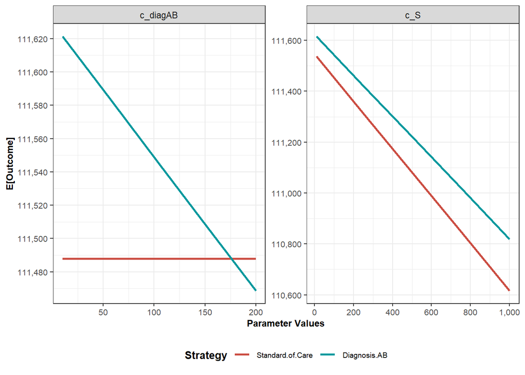

```r
# Plot OWSA and store it in an object
gg_owsa <- plot(owsa_nmb, txtsize = 10, n_x_ticks = 4,
                facet_scales = "free") +
           theme(legend.position = "bottom")

# Display the plot
print(gg_owsa)
```

```r
# Save the plot as PNG in figs/ directory
ggsave("figs/owsa_nmb.png", plot = gg_owsa, width = 10, height = 8, dpi = 300)
```

## 9.4 Two-way sensitivity analysis (TWSA)

```r
# dataframe containing all parameters, their basecase values, and the min and
# max values of the parameters of interest
df_params_twsa <- data.frame(pars = c("c_diagSoC", "c_diagAB"),
                             min  = c(10, 30),  # min parameter values
                             max  = c(100, 200) # max parameter values
                             )

twsa_nmb <- run_twsa_det(params_range    = df_params_twsa,    # dataframe with parameters for TWSA
                         params_basecase = l_params_all,      # list with all parameters
                         nsamp           = 10,                # number of parameter values
                         FUN             = calculate_ce_out,  # function to compute outputs
                         outcomes        = "NMB",             # output to do the TWSA on
                         strategies      = l_params_all$v_names_str,       # names of the strategies
                         n_wtp           = 3000)              # extra argument to pass to FUN
```

[output not shown]

### 9.4.1 Plot TWSA

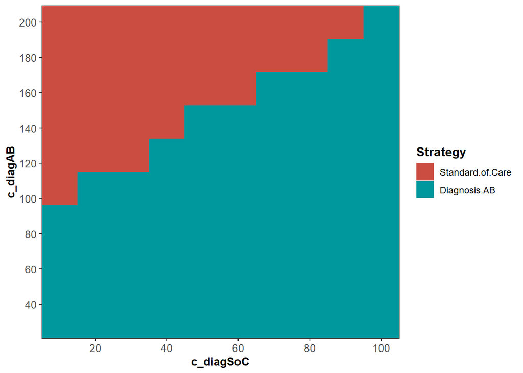

```r
# Plot TWSA and store it in an object
gg_twsa <- plot(twsa_nmb)

# Display the plot
print(gg_twsa)
```

```r
# Save the plot as PNG in figs/ directory
ggsave("figs/twsa_nmb.png", plot = gg_twsa, width = 10, height = 8, dpi = 300)
```

- Diagnosis AB is cost-effective in most cases, except when its diagnostic costs (c_diagAB) are high (above ~100), and Standard of Care diagnosis (c_diagSoC) remains low.
- If c_diagAB continues rising above 200+, Standard of Care is preferable.
- To ensure Diagnosis AB remains cost-effective, controlling diagnostic costs is crucial.

# 10 Probabilistic Sensitivity Analysis (PSA)

## 10.1 Model input

```r
# Store the parameter names into a vector
v_names_params <- names(l_params_all)

## Test functions to generate CE outcomes and PSA dataset
# Test function to compute CE outcomes
calculate_ce_out(l_params_all)
```

```
##           Strategy      Cost   Effect      NMB
## 1 Standard of Care  990.4161 22.49565 111487.8
## 2     Diagnosis AB 1016.3008 22.51788 111573.1
```

```r
# Test function to generate PSA input dataset
generate_psa_params(n_sim = 10)
```

```
##           p_HS  p_SH_SoC p_SH_diagAB      c_H      c_S c_D c_diagSoC c_diagAB
## 1  0.010129149 0.1261909   0.3187079 37.43157 33.65350   0       7.5 9.166667
## 2  0.008783991 0.1536248   0.1922123 41.16341 36.68617   0       7.5 9.166667
## 3  0.007956009 0.1227398   0.2752293 42.07640 39.04775   0       7.5 9.166667
## 4  0.008955925 0.1381371   0.2081659 38.92869 47.39211   0       7.5 9.166667
## 5  0.007589847 0.1792619   0.1573499 46.42038 39.15738   0       7.5 9.166667
## 6  0.008514210 0.1412811   0.2413785 38.11805 39.97034   0       7.5 9.166667
## 7  0.010175229 0.2174230   0.2529562 45.31142 35.77252   0       7.5 9.166667
## 8  0.008531863 0.1442373   0.1723210 39.15135 37.21269   0       7.5 9.166667
## 9  0.008149820 0.1911385   0.2389196 41.58179 45.38947   0       7.5 9.166667
## 10 0.008930551 0.1796629   0.1960181 38.38244 47.63179   0       7.5 9.166667
##    u_H       u_S u_D  u_diagAB
## 1    1 0.8447763   0 0.8500000
## 2    1 0.8719877   0 0.8810480
## 3    1 0.8235081   0 0.8615984
## 4    1 0.8458942   0 0.8664554
## 5    1 0.8710065   0 0.8738993
## 6    1 0.8364267   0 0.8743519
## 7    1 0.8636281   0 0.8890828
## 8    1 0.8224369   0 0.8500000
## 9    1 0.8262598   0 0.8500000
## 10   1 0.8435764   0 0.8609238
```

```r
## Generate PSA dataset
# Number of simulations
n_sim <- 100

# Generate PSA input dataset
df_psa_input <- generate_psa_params(n_sim = n_sim)
# First six observations
head(df_psa_input)
```

```
##          p_HS  p_SH_SoC p_SH_diagAB      c_H      c_S c_D c_diagSoC c_diagAB
## 1 0.010129149 0.1679614   0.2406108 39.48376 43.64875   0       7.5 9.166667
## 2 0.008783991 0.1418485   0.2121985 35.59746 42.68222   0       7.5 9.166667
## 3 0.007956009 0.3187079   0.1763467 35.76987 38.21917   0       7.5 9.166667
## 4 0.008955925 0.1526749   0.1499672 45.98295 39.91541   0       7.5 9.166667
## 5 0.007589847 0.1835629   0.2385309 43.87849 36.62150   0       7.5 9.166667
## 6 0.008514210 0.1970752   0.2080123 46.16301 41.46363   0       7.5 9.166667
##   u_H       u_S u_D  u_diagAB
## 1   1 0.8000000   0 0.8500000
## 2   1 0.8277176   0 0.8500000
## 3   1 0.8580888   0 0.8507415
## 4   1 0.8519930   0 0.8709304
## 5   1 0.8757554   0 0.8500000
## 6   1 0.8961588   0 0.8727081
```

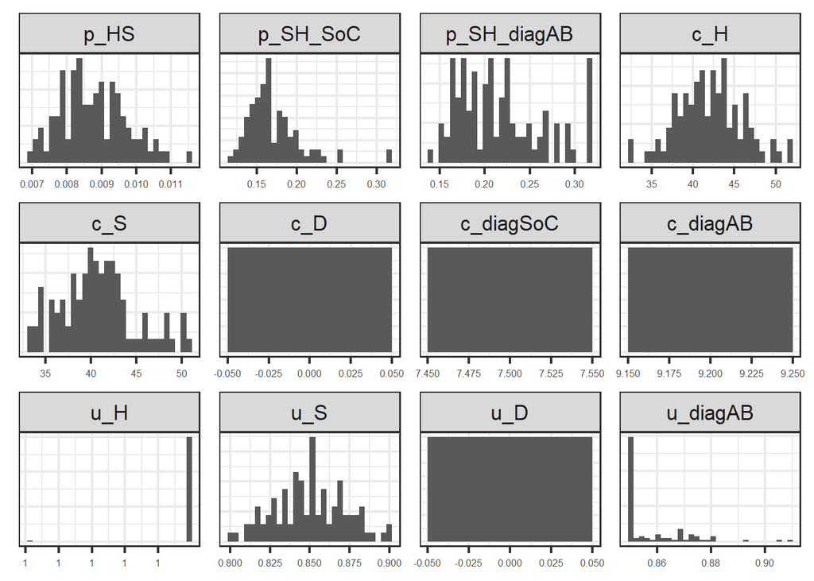

```r
### Histogram of parameters
gg_hist <- ggplot(melt(df_psa_input, variable.name = "Parameter"), aes(x = value)) +
  facet_wrap(~Parameter, scales = "free") +
  geom_histogram(aes(y = ..density..)) +
  ylab("") +
  theme_bw(base_size = 16) +
  theme(axis.text = element_text(size = 6),
        axis.title.x = element_blank(),
        axis.title.y = element_blank(),
        axis.text.y  = element_blank(),
        axis.ticks.y = element_blank())
# Display the plot
print(gg_hist)
```

```r
# Save the plot as PNG in figs/ directory
ggsave("figs/histogram_parameters.png", plot = gg_hist, width = 10, height = 8, dpi = 300)
```

- The PSA accounts for parameter uncertainty by sampling from different distributions.
- Transition probabilities, costs, and utilities show expected distributions, with cost parameters often following normal or uniform distributions.
- This analysis helps evaluate decision uncertainty and variability in model outcomes, ensuring more robust cost-effectiveness results.

## 10.2 Run PSA

```r
# Initialize data.frames with PSA output

n_str       <- length(l_params_all$v_names_str)
v_names_str <- l_params_all$v_names_str
# data.frame of costs
df_c <- as.data.frame(matrix(0,
                             nrow = n_sim,
                             ncol = n_str))
colnames(df_c) <- v_names_str
# data.frame of effectiveness
df_e <- as.data.frame(matrix(0,
                             nrow = n_sim,
                             ncol = n_str))
colnames(df_e) <- v_names_str

# Conduct probabilistic sensitivity analysis
# Run Markov model on each parameter set of PSA input dataset
n_time_init_psa_series <- Sys.time()

for (i in 1:n_sim) { # i <- 1
  l_psa_input <- update_param_list(l_params_all, df_psa_input[i,])
  # Outcomes
  l_out_ce_temp  <- calculate_ce_out(l_psa_input)
  df_c[i, ]  <- l_out_ce_temp$Cost
  df_e[i, ]  <- l_out_ce_temp$Effect
  # Display simulation progress
  if (i/(n_sim/100) == round(i/(n_sim/100), 0)) { # display progress every 5%
    cat('\r', paste(i/n_sim * 100, "% PSA for microsim done", sep = " "))
  }
}
```

[output not shown]

```r
n_time_end_psa_series <- Sys.time()
n_time_total_psa_series <- n_time_end_psa_series - n_time_init_psa_series
print(paste0("PSA with ", scales::comma(n_sim), " simulations run in series in ",
             round(n_time_total_psa_series, 2), " ",
             units(n_time_total_psa_series)))
```

```
## [1] "PSA with 100 simulations run in series in 59.49 secs"
```

# 10.3 Visualize PSA results for CEA

```r
### Create PSA object
l_psa <- make_psa_obj(cost          = df_c,
                      effectiveness = df_e,
                      parameters    = df_psa_input,
                      strategies    = v_names_str)
l_psa$strategies <- v_names_str
colnames(l_psa$effectiveness) <- v_names_str
colnames(l_psa$cost) <- v_names_str

# Vector with willingness-to-pay (WTP) thresholds.
v_wtp <- seq(0, 2000, by = 100)
```

## 10.3.1 Cost-Effectiveness Scatter plot

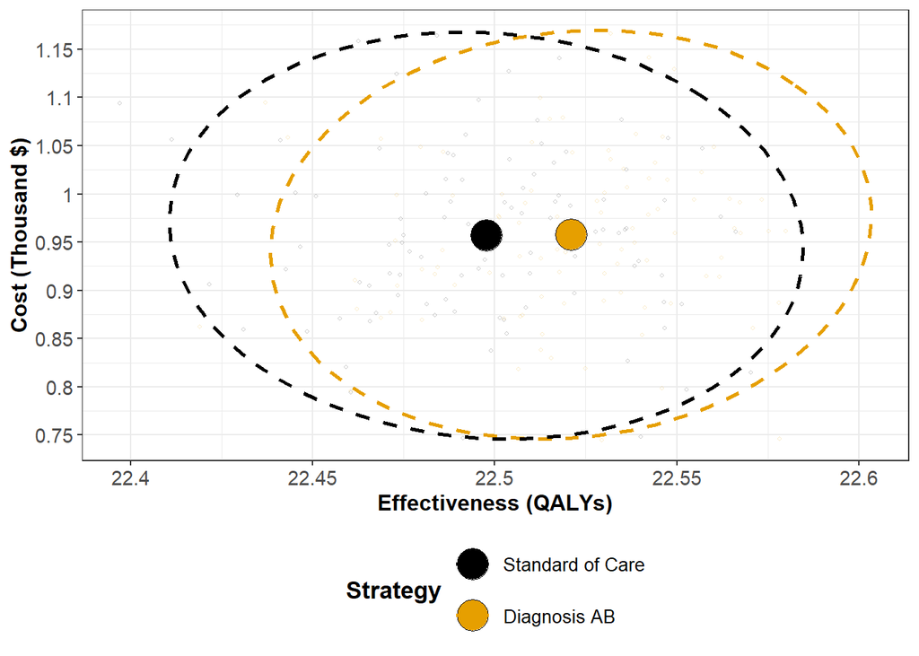

```r
### Cost-Effectiveness Scatter plot
txtsize <- 13
gg_scatter <- plot_psa(l_psa, txtsize = txtsize) +
  ggthemes::scale_color_colorblind() +
  ggthemes::scale_fill_colorblind() +
  scale_y_continuous("Cost (Thousand $)",
                     breaks = number_ticks(10),
                     labels = function(x) x/1000) +
  xlab("Effectiveness (QALYs)") +
  guides(col = guide_legend(nrow = 2)) +
  theme(legend.position = "bottom")
# Display the plot
print(gg_scatter)
```

```r
# Save the plot as PNG in figs/ directory
ggsave("figs/cost_effectiveness_scatter.png", plot = gg_scatter, width = 8, height = 6, dpi = 300)
```

- Diagnosis AB is slightly more costly but marginally more effective than Standard of Care.
- Uncertainty in cost-effectiveness estimates is considerable, with overlap between strategies.
- Decision-makers should consider WTP thresholds—if small effectiveness gains justify higher costs, Diagnosis AB may be favored. Otherwise, Standard of Care remains a reasonable choice.

## 10.3.2 Incremental cost-effectiveness ratios (ICERs) with probabilistic output

```r
### Incremental cost-effectiveness ratios (ICERs) with probabilistic output
# Compute expected costs and effects for each strategy from the PSA
df_out_ce_psa <- summary(l_psa)

# Compute ICERs
df_cea_psa <- calculate_icers(cost       = df_out_ce_psa$meanCost,
                              effect     = df_out_ce_psa$meanEffect,
                              strategies = df_out_ce_psa$Strategy)

# Display the table
print(df_cea_psa)
```

```
##           Strategy     Cost   Effect  Inc_Cost Inc_Effect     ICER Status
## 1 Standard of Care 956.9898 22.49767        NA         NA       NA     ND
## 2     Diagnosis AB 957.7812 22.52092 0.7914174 0.02325415 34.03338     ND
```

```r
# Save the table as a CSV file in the tables/ directory
write.csv(df_cea_psa, "tables/icer_results.csv", row.names = FALSE)
```

## 10.3.3 Plot cost-effectiveness frontier with probabilistic output

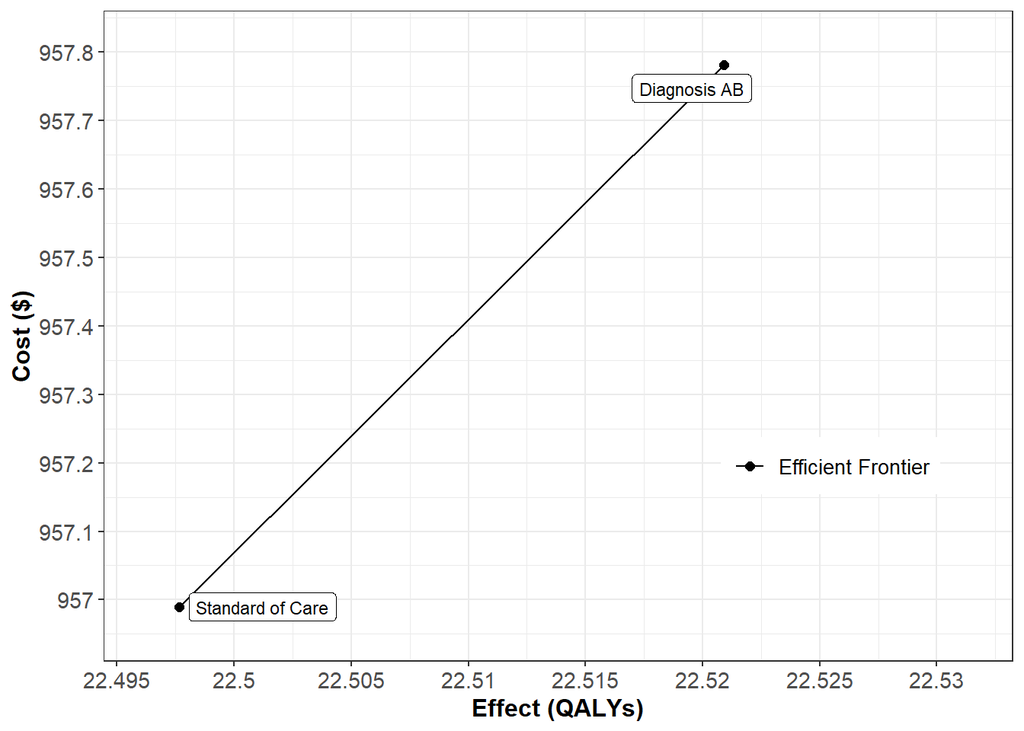

```r
# Plot cost-effectiveness frontier with probabilistic output
gg_icers <- plot_icers(df_cea_psa, label = "all", txtsize = txtsize) +
  expand_limits(x = c(22.52, 22.53)) +
  theme(legend.position = c(0.8, 0.3))

# Display the plot
print(gg_icers)
```

```r
# Save the plot in figs/ directory as a PNG file
ggsave("figs/cost_effectiveness_frontier.png", plot = gg_icers, width = 8, height = 6, dpi = 300)
```

- The plot shows that Diagnosis AB is slightly more effective than Standard of Care in terms of QALYs but comes at a marginally higher cost. Since both strategies lie on the efficient frontier, neither is dominated, meaning both remain viable options depending on the willingness-to-pay (WTP) threshold.
- The x-axis is zoomed into to enhance visibility of the small differences in QALYs

## 10.3.4 Cost-effectiveness acceptability curves (CEACs) and frontier (CEAF)

This figure shows the Cost-effectiveness acceptability curves. The CEAC shows the probability that a specific strategy is cost-effective (based on all results from the PSA iterations). The cost-effectiveness frontier consist of the set of points corresponding to treatment alternatives taht are considered cost-effective at differnet values of the WTP threshold.

```r
### Cost-effectiveness acceptability curves (CEACs) and frontier (CEAF)
ceac_obj <- ceac(wtp = v_wtp, psa = l_psa)
# Regions of highest probability of cost-effectiveness for each strategy
summary(ceac_obj)
```

```
##   range_min range_max   cost_eff_strat
## 1         0       100 Standard of Care
## 2       100      2000     Diagnosis AB
```

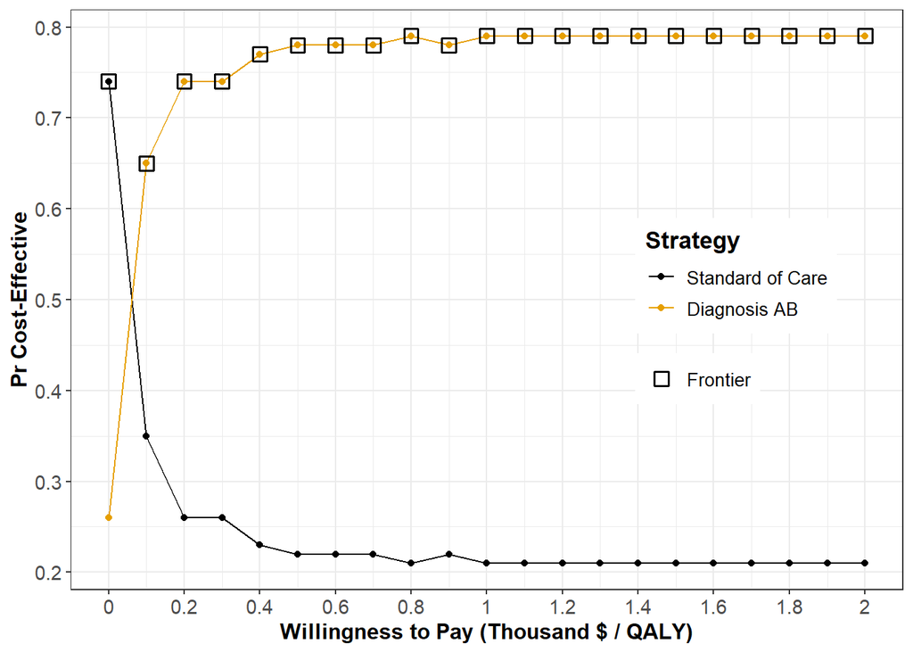

```r
# CEAC & CEAF plot
gg_ceac <- plot_ceac(ceac_obj, txtsize = txtsize, xlim = c(0, NA), n_x_ticks = 14) +
  ggthemes::scale_color_colorblind() +
  ggthemes::scale_fill_colorblind() +
  theme(legend.position = c(0.8, 0.48))
# Display the plot
print(gg_ceac)
```

```r
# Save the plot in figs/ directory as a PNG file
ggsave("figs/ceac_plot.png", plot = gg_ceac, width = 8, height = 6, dpi = 300)
```

- If the WTP is below $100 per QALY, Standard of Care is more likely to be the cost-effective choice.
- If WTP is above $100 per QALY, DiagnosisAB becomes the dominant strategy in terms of cost-effectiveness.
- Decision-makers with a higher budget for health interventions should prioritize Diagnosis AB, as it offers better value for money at most WTP levels.

# Acknowlegdement

For this work we made use of the template developed by the Decision Analysis in R for Technologies in Health (DARTH) workgroup: http://darthworkgroup.com.

The notation of our code is based on the following provided framework and coding convention: Alarid-Escudero, F., Krijkamp, E., Pechlivanoglou, P. et al. A Need for Change! A Coding Framework for Improving Transparency in Decision Modeling. PharmacoEconomics 37, 1329–1339 (2019). https://doi.org/10.1007/s40273-019-00837-x.

- Alarid-Escudero F, Krijkamp EM, Enns EA, Yang A, Hunink MGM Pechlivanoglou P, Jalal H. An Introductory Tutorial on Cohort State-Transition Models in R Using a Cost-Effectiveness Analysis Example. Medical Decision Making, 2023; 43(1). (Epub). https://doi.org/10.1177/0272989X221103163
- Alarid-Escudero F, Krijkamp EM, Enns EA, Yang A, Hunink MGM Pechlivanoglou P, Jalal H. A Tutorial on Time-Dependent Cohort State-Transition Models in R using a Cost-Effectiveness Analysis Example. Medical Decision Making, 2023; 43(1). https://doi.org/10.1177/0272989X221121747

Other work from DARTH can be found on the website: http://darthworkgroup.com/publications/

# Copyright for assignment work

Copyright 2017, THE HOSPITAL FOR SICK CHILDREN AND THE COLLABORATING INSTITUTIONS.All rights reserved in Canada, the United States and worldwide. Copyright, trademarks, trade names and any and all associated intellectual property are exclusively owned by THE HOSPITAL FOR Sick CHILDREN and the collaborating institutions. These materials may be used, reproduced, modified, distributed and adapted with proper attribution.